# CMPINF 2130 Summer 2021 - Extra examples

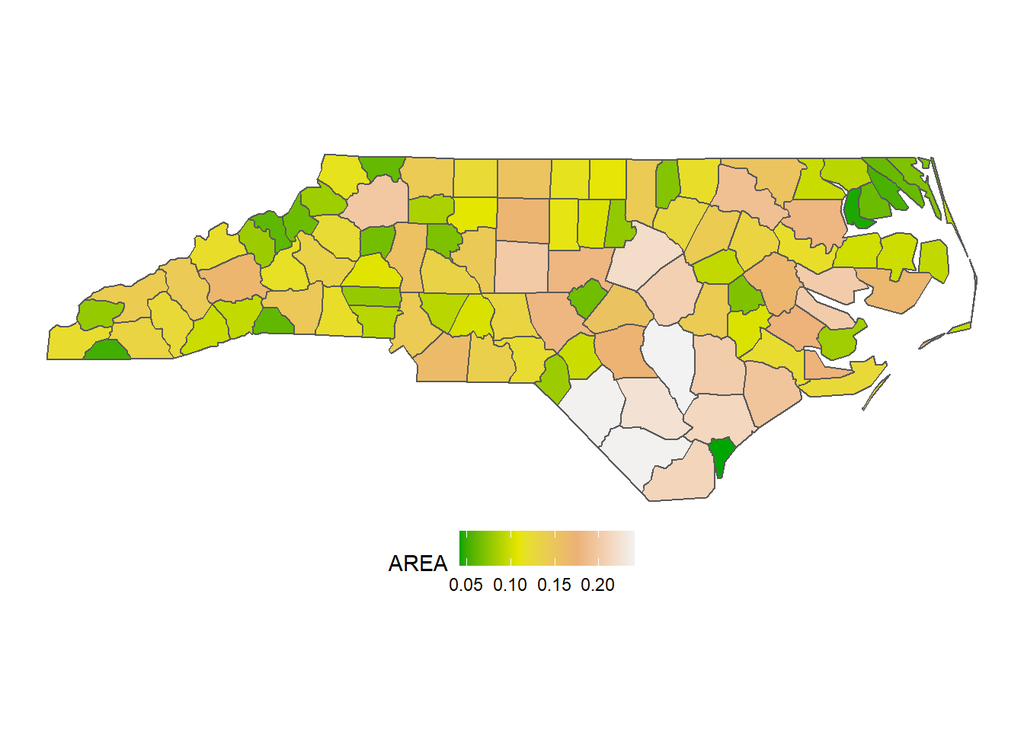

```r
nc %>%
  ggplot() +
  geom_sf(mapping = aes(fill = AREA)) +
  scale_fill_gradientn(colours = terrain.colors(4)) +
  theme_void() +
  theme(legend.position = "bottom")
```

Creating a choropleth for another field with `geom_sf()` requires mapping a different field to the `fill` aesthetic. The choropleth for `BIR74` is shown below.

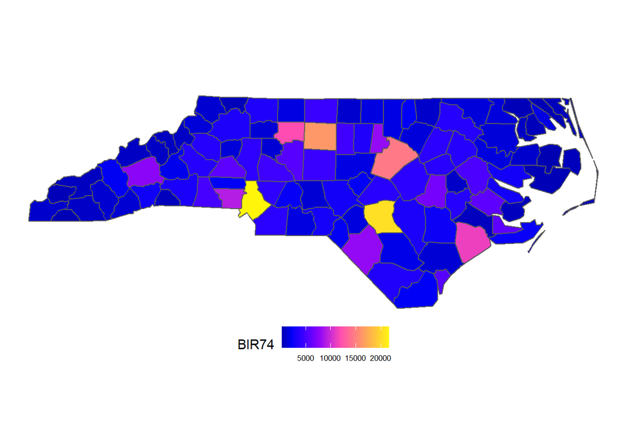

```r
nc %>%
  ggplot() +
  geom_sf(mapping = aes(fill = BIR74)) +
  scale_fill_gradientn(colours = sf.colors(12)) +
  theme_void() +
  theme(legend.position = "bottom") +
  theme(legend.text = element_text(size = 6.5))
```

Creating subplots via facets with `ggplot2` requires reshaping the `sf` object. Unfortunately, the newest `tidyverse` reshaping function `pivot_longer()` does not work perfectly with `sf` objects. We must use the slightly older, `tidyr::gather()` function to reshape into a longer format. `tidyr::gather()` creates an object similar to `pivot_longer()`, but it requires that we specify what we “do not want to gather” into the reshaped column. The minus sign operator, `-`, is used to identify the columns to “not gather”. The code chunk below demonstrates selecting the `geom` and column and both `BIR74` and `BIR79` columns. The two `BIR` columns are “gathered together” by specifying `-geom` in the `gather()` call.

```r
nc %>%
  select(geom, starts_with("BIR")) %>%
  tidyr::gather(key = "key", value = "value", -geom)
```

```
## Simple feature collection with 200 features and 2 fields
## Geometry type: MULTIPOLYGON
## Dimension:     XY
## Bounding box:  xmin: -84.32385 ymin: 33.88199 xmax: -75.45698 ymax: 36.58965
## Geodetic CRS:  NAD27
## First 10 features:
##      key value                           geom
## 1  BIR74  1091 MULTIPOLYGON (((-81.47276 3...
## 2  BIR74   487 MULTIPOLYGON (((-81.23989 3...
## 3  BIR74  3188 MULTIPOLYGON (((-80.45634 3...
## 4  BIR74   508 MULTIPOLYGON (((-76.00897 3...
## 5  BIR74  1421 MULTIPOLYGON (((-77.21767 3...
## 6  BIR74  1452 MULTIPOLYGON (((-76.74506 3...
## 7  BIR74   286 MULTIPOLYGON (((-76.00897 3...
## 8  BIR74   420 MULTIPOLYGON (((-76.56251 3...
## 9  BIR74   968 MULTIPOLYGON (((-78.30876 3...
## 10 BIR74  1612 MULTIPOLYGON (((-80.02567 3...
```

As we can see above, each feature is now associated with a `key`. We will facet the `geom_sf()` choropleth by the `key` column to create a separate facet for each `BIR` variable.

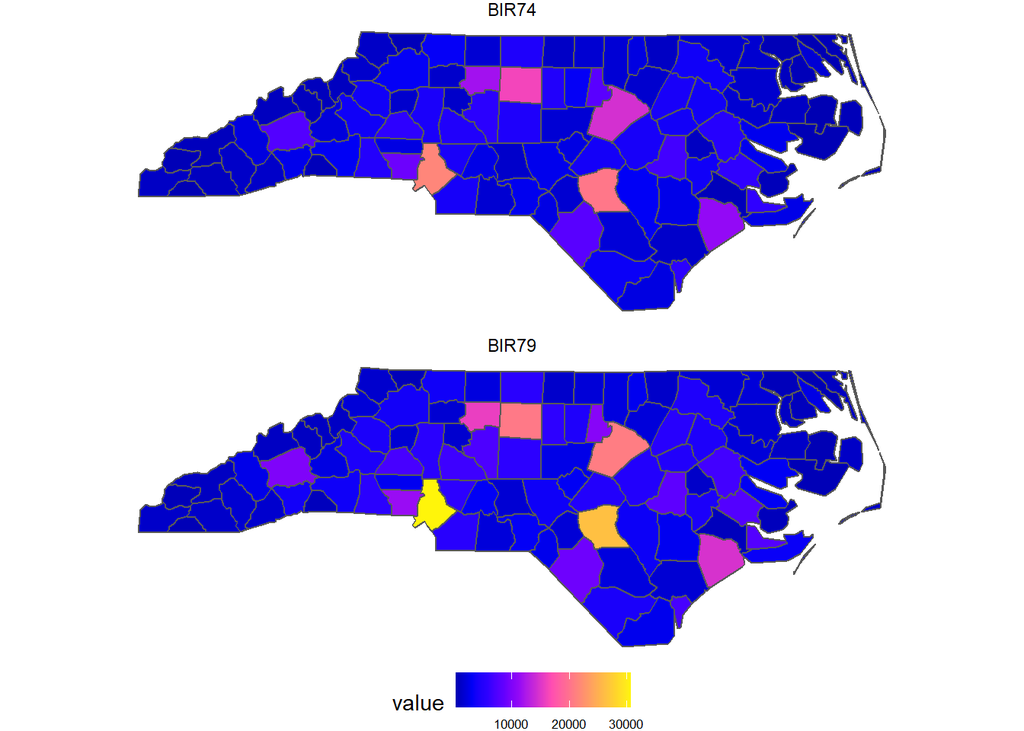

```r
nc %>%
  select(geom, starts_with("BIR")) %>%
  tidyr::gather(key = "key", value = "value", -geom) %>%
  ggplot() +
  geom_sf(mapping = aes(fill = value)) +
  facet_wrap(~key, ncol = 1) +
  scale_fill_gradientn(colours = sf.colors(12)) +
  theme_void() +
  theme(legend.position = "bottom") +
  theme(legend.text = element_text(size = 6.5))
```

### other sf examples

The Simple Features concept is quite flexible. It allows storing spatial data at more fine grain detail than just countries, states, and counties. For example, the `tidycensus` package demonstrates how to visualize US Census data and American Community Survey (ACS) data at the census tract level within a county. Please the [spatial data in tidycensus](https://walker-data.com/tidycensus/articles/spatial-data.html) for an introduction, and the [tidycensus documentation](https://walker-data.com/tidycensus/index.html) in general for an overview.

## Other plotting packages

### plotly

The `plotly` package includes many different approaches for visualizing maps. The [Chapter 4](https://plotly-r.com/maps.html#maps-integrated) of the plotly-r book provides an excellent introduction to making maps with plotly and so those examples will not be repeated here.

### tmap

The `tmap` package is another popular map package. In produces high quality production ready maps. Please see the [getting started vignette](https://cran.r-project.org/web/packages/tmap/vignettes/tmap-getstarted.html) for an introduction the [tmap CRAN page](https://cran.r-project.org/web/packages/tmap/index.html) for a complete set of vignettes.

We will show just a few examples in this report. Therefore, if you would like to run the code below you must first download and install the `tmap` package.

Let’s start by loading `tmap`.

```r
library(tmap)
```

`tmap` visualizations can work with simple feature `sf` objects. The North Carolina county map can therefore be visualized with the `qtm()` function, as shown below.

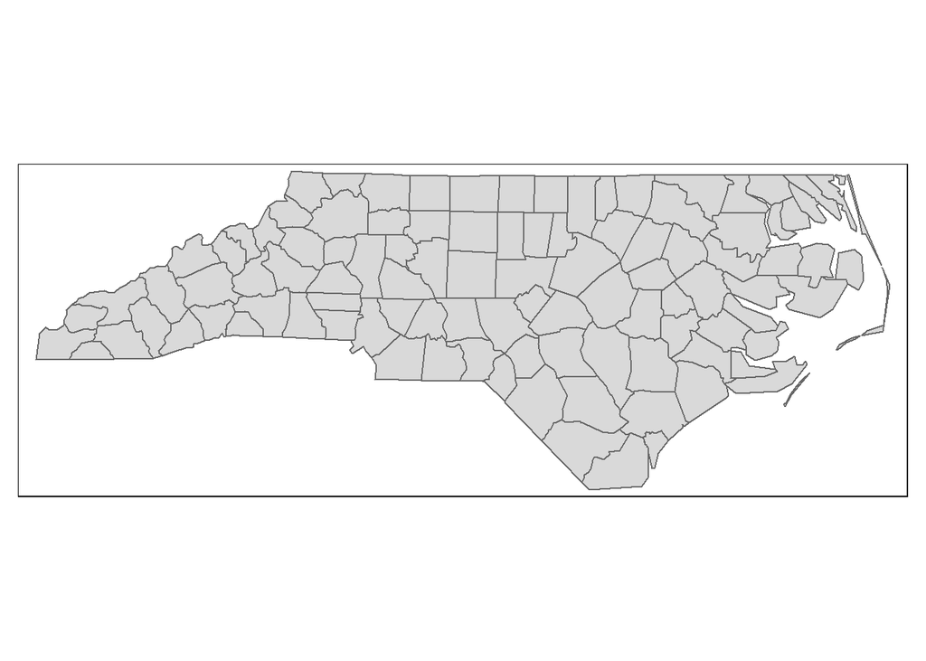

```r
qtm(nc)
```

`tmap` also support interactive plots, similar to `plotly`. An interactive choropleth of the `BIR74` field from the `nc` object is shown below. The first step is to make the `tmap_mode()` a `'view'` mode.

```r
tmap_mode("view")
```

```
## tmap mode set to interactive viewing
```

Then, the `tm_shape()` and `tm_fill()` functions can be added together in the style of adding graphical layers on top of each other. The interactive view is particularly neat because the default “grey” area background can be replaced with a street map or topographical map.

```r
tm_shape(nc) + tm_fill("BIR74", palette = sf.colors(12))
```

[interactive chart not shown]

### cartograms

Choropleths can be altered so that the spatial sizes of the states or countries are distorted based another field. These types of maps are known as **cartograms**. You might have seen such visualizations with election results where the state sizes represent population instead of land area. [Section 4.2.2](https://plotly-r.com/maps.html#cartograms) in the plotly-r book shows how to create cartograms in `R` using the `cartogram` package.

## Example application

The maps we have visualized so far have worked with specially crafted spatial data. We have focused on either visualizing the region boundaries, or the choropleths showed fields already linked with the simple features object. However, we may wish to visualize data spatially that are not linked to spatial information. We must therefore join the data of interest with appropriate spatial data objects in order to create the maps.

We will use a baseball example to demonstrate how to do this. The data comes from the `Lahman` package, and so you must download and install `Lahman` in order to run the code for this example.

### Lahman data

The `Lahman` package is loaded in the code chunk below.

```r
library(Lahman)
```

The `Lahman` package includes multiple data sets associated with every player and every season of Major League Baseball (MLB). We will focus on the `Master` table which contains biographic information about every player that has ever played in the MLB. One row of `Master` corresponds to a player. A glimpse of the `Master` table is shown below.

```r
Master %>% glimpse()
```

```
## Rows: 20,093
## Columns: 26
## $ playerID     <chr> "aardsda01", "aaronha01", "aaronto01", "aasedo01", "abada~
## $ birthYear    <int> 1981, 1934, 1939, 1954, 1972, 1985, 1850, 1877, 1869, 186~
## $ birthMonth   <int> 12, 2, 8, 9, 8, 12, 11, 4, 11, 10, 3, 10, 2, 8, 9, 6, 2, ~
## $ birthDay     <int> 27, 5, 5, 8, 25, 17, 4, 15, 11, 14, 16, 22, 16, 17, 19, 2~
## $ birthCountry <chr> "USA", "USA", "USA", "USA", "USA", "D.R.", "USA", "USA", ~
## $ birthState   <chr> "CO", "AL", "AL", "CA", "FL", "La Romana", "PA", "PA", "V~
## $ birthCity    <chr> "Denver", "Mobile", "Mobile", "Orange", "Palm Beach", "La~
## $ deathYear    <int> NA, 2021, 1984, NA, NA, NA, 1905, 1957, 1962, 1926, 1930,~
## $ deathMonth   <int> NA, 1, 8, NA, NA, NA, 5, 1, 6, 4, 2, 6, NA, NA, NA, NA, N~
## $ deathDay     <int> NA, 22, 16, NA, NA, NA, 17, 6, 11, 27, 13, 11, NA, NA, NA~
## $ deathCountry <chr> NA, "USA", "USA", NA, NA, NA, "USA", "USA", "USA", "USA",~
## $ deathState   <chr> NA, "GA", "GA", NA, NA, NA, "NJ", "FL", "VT", "CA", "MI",~
## $ deathCity    <chr> NA, "Atlanta", "Atlanta", NA, NA, NA, "Pemberton", "Fort ~
## $ nameFirst    <chr> "David", "Hank", "Tommie", "Don", "Andy", "Fernando", "Jo~
## $ nameLast     <chr> "Aardsma", "Aaron", "Aaron", "Aase", "Abad", "Abad", "Aba~
## $ nameGiven    <chr> "David Allan", "Henry Louis", "Tommie Lee", "Donald Willi~
## $ weight       <int> 215, 180, 190, 190, 184, 235, 192, 170, 175, 169, 190, 18~
## $ height       <int> 75, 72, 75, 75, 73, 74, 72, 71, 71, 68, 71, 70, 78, 74, 7~
## $ bats         <fct> R, R, R, R, L, L, R, R, R, L, R, R, R, R, L, R, L, L, R, ~
## $ throws       <fct> R, R, R, R, L, L, R, R, R, L, R, R, R, L, L, R, L, R, R, ~
## $ debut        <chr> "2004-04-06", "1954-04-13", "1962-04-10", "1977-07-26", "~
## $ finalGame    <chr> "2015-08-23", "1976-10-03", "1971-09-26", "1990-10-03", "~
## $ retroID      <chr> "aardd001", "aaroh101", "aarot101", "aased001", "abada001~
## $ bbrefID      <chr> "aardsda01", "aaronha01", "aaronto01", "aasedo01", "abada~
## $ deathDate    <date> NA, 2021-01-22, 1984-08-16, NA, NA, NA, 1905-05-17, 1957~
## $ birthDate    <date> 1981-12-27, 1934-02-05, 1939-08-05, 1954-09-08, 1972-08-~
```

The `birthCountry` column gives the name of the country the player was born in. The `birthState` gives the name of the state within the country. We will start out by focusing on players born in the USA. We can visualize the number of MLB players from each state with a bar chart.

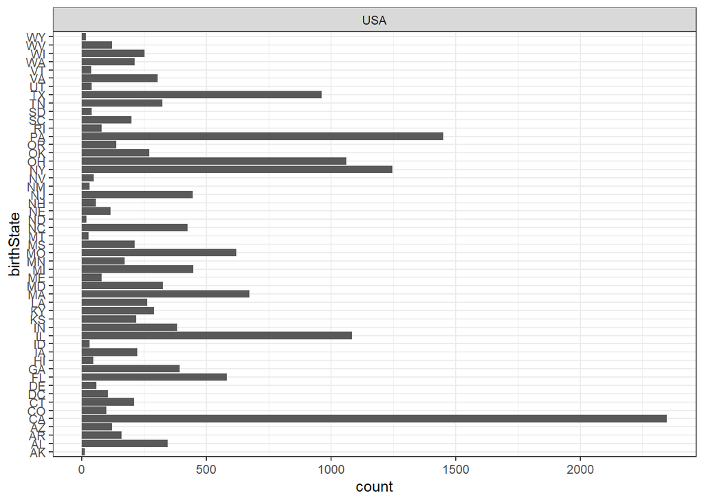

```r
Master %>%
  filter(birthCountry == "USA") %>%
  ggplot(mapping = aes(y = birthState)) +
  geom_bar() +
  facet_wrap(~birthCountry) +
  theme_bw()
```

There’s nothing wrong with the above bar chart. It is quite useful. However, it might also be interesting to visualize the counts on a map as a choropleth. The map will communicate spatial information so that we may assess if: states close together produce similar numbers of professional MLB players.

We can create the appropriate counts by using `count()` or with `group_by()` and `summarize()`. The code chunk below uses the `count()` function.

```r
Master %>%
  filter(birthCountry == "USA") %>%
  count(birthState) %>%
  arrange(desc(n))
```

```
##    birthState    n
## 1          CA 2348
## 2          PA 1451
## 3          NY 1246
## 4          IL 1084
## 5          OH 1062
## 6          TX  962
## 7          MA  671
## 8          MO  619
## 9          FL  581
## 10         MI  446
## 11         NJ  444
## 12         NC  423
## 13         GA  392
## 14         IN  381
```

[output cut: 37 more lines]

As the example output displayed above shows, the summarized count data consists of two columns: the state abbreviation and the count. We need to merge or **join** this information to spatial data in order to visualize the counts as a choropleth.

### map with geom_polygon()

One approach is to work with the “tidy” long-format spatial data already suited for `ggplot2`. The `us48` data set has the spatial information for the 48 contiguous states, as we previously saw. It therefore does not include Alaska and Hawaii, but it will serve to demonstrate the process. Let’s check the names of the columns in `us48`:

```r
us48 %>% names()
```

```
## [1] "long"      "lat"       "group"     "order"     "region"    "subregion"
```

If we recall from earlier in this report, the `region` variable corresponds to the state name:

```r
us48 %>% head()
```

```
##        long      lat group order  region subregion
## 1 -87.46201 30.38968     1     1 alabama      <NA>
## 2 -87.48493 30.37249     1     2 alabama      <NA>
## 3 -87.52503 30.37249     1     3 alabama      <NA>
## 4 -87.53076 30.33239     1     4 alabama      <NA>
## 5 -87.57087 30.32665     1     5 alabama      <NA>
## 6 -87.58806 30.32665     1     6 alabama      <NA>
```

As we see above though, the `region` variable consists of the state name in lower case letters. We can confirm this using `count()`.

```r
us48 %>% count(region)
```

```
##                  region    n
## 1               alabama  202
## 2               arizona  149
## 3              arkansas  312
## 4            california  516
## 5              colorado   79
## 6           connecticut   91
## 7              delaware   94
## 8  district of columbia   10
## 9               florida  872
## 10              georgia  381
## 11                idaho  233
## 12             illinois  329
## 13              indiana  257
## 14                 iowa  256
```

[output cut: 35 more lines]

This means the spatial data, `us48`, and the player summaries do not share a common variable or *key* that we can use to join with. We must therefore create use a *link table* to enable joining the two together. This link table consists of a column with the state name and a column for the abbreviation. Base `R` includes two vectors, `state.name` and `state.abb`, that consist of these two pieces of information! The state names are shown below:

```r
state.name
```

```
##  [1] "Alabama"        "Alaska"         "Arizona"        "Arkansas"
##  [5] "California"     "Colorado"       "Connecticut"    "Delaware"
##  [9] "Florida"        "Georgia"        "Hawaii"         "Idaho"
## [13] "Illinois"       "Indiana"        "Iowa"           "Kansas"
## [17] "Kentucky"       "Louisiana"      "Maine"          "Maryland"
## [21] "Massachusetts"  "Michigan"       "Minnesota"      "Mississippi"
## [25] "Missouri"       "Montana"        "Nebraska"       "Nevada"
## [29] "New Hampshire"  "New Jersey"     "New Mexico"     "New York"
## [33] "North Carolina" "North Dakota"   "Ohio"           "Oklahoma"
## [37] "Oregon"         "Pennsylvania"   "Rhode Island"   "South Carolina"
## [41] "South Dakota"   "Tennessee"      "Texas"          "Utah"
## [45] "Vermont"        "Virginia"       "Washington"     "West Virginia"
## [49] "Wisconsin"      "Wyoming"
```

We can force all characters to lower case using the `stringr::str_to_lower()` function. `stringr` is a package within the `tidyverse` and so you should have it already.

```r
stringr::str_to_lower(state.name)
```

```
##  [1] "alabama"        "alaska"         "arizona"        "arkansas"
##  [5] "california"     "colorado"       "connecticut"    "delaware"
##  [9] "florida"        "georgia"        "hawaii"         "idaho"
## [13] "illinois"       "indiana"        "iowa"           "kansas"
## [17] "kentucky"       "louisiana"      "maine"          "maryland"
## [21] "massachusetts"  "michigan"       "minnesota"      "mississippi"
## [25] "missouri"       "montana"        "nebraska"       "nevada"
## [29] "new hampshire"  "new jersey"     "new mexico"     "new york"
## [33] "north carolina" "north dakota"   "ohio"           "oklahoma"
## [37] "oregon"         "pennsylvania"   "rhode island"   "south carolina"
## [41] "south dakota"   "tennessee"      "texas"          "utah"
## [45] "vermont"        "virginia"       "washington"     "west virginia"
## [49] "wisconsin"      "wyoming"
```

The state abbreviations are:

```r
state.abb
```

```
##  [1] "AL" "AK" "AZ" "AR" "CA" "CO" "CT" "DE" "FL" "GA" "HI" "ID" "IL" "IN" "IA"
## [16] "KS" "KY" "LA" "ME" "MD" "MA" "MI" "MN" "MS" "MO" "MT" "NE" "NV" "NH" "NJ"
## [31] "NM" "NY" "NC" "ND" "OH" "OK" "OR" "PA" "RI" "SC" "SD" "TN" "TX" "UT" "VT"
## [46] "VA" "WA" "WV" "WI" "WY"
```

The link table is created in the code chunk below.

```r
state_link <- tibble::tibble(
  name = stringr::str_to_lower(state.name),
  abbrev = state.abb
)
```

We can now join the state name to the summarized state counts via a `left_join()` as shown below.

```r
Master %>%
  filter(birthCountry == "USA") %>%
  count(birthState) %>%
  left_join(state_link, by = c("birthState" = "abbrev"))
```

```
##    birthState    n           name
## 1          AK   12         alaska
## 2          AL  344        alabama
## 3          AR  160       arkansas
## 4          AZ  121        arizona
## 5          CA 2348     california
## 6          CO   98       colorado
## 7          CT  209    connecticut
## 8          DC  104           <NA>
## 9          DE   57       delaware
## 10         FL  581        florida
## 11         GA  392        georgia
## 12         HI   46         hawaii
## 13         IA  223           iowa
## 14         ID   30          idaho
```

[output cut: 37 more lines]

And finally we can join the state summarized counts to the `us48` data. The code chunk below uses `right_join()` to join to the larger `us48` data set. Notice that the data manipulation pipeline uses the link table as the intermediary between the two data sets of interest.

```r
Master %>%
  filter(birthCountry == "USA") %>%
  count(birthState) %>%
  left_join(state_link, by = c("birthState" = "abbrev")) %>%
  select(name, num_players = n) %>%
  right_join(us48,
             by = c("name" = "region")) %>%
  glimpse()
```

```
## Rows: 15,537
## Columns: 7
## $ name        <chr> "alabama", "alabama", "alabama", "alabama", "alabama", "al~
## $ num_players <int> 344, 344, 344, 344, 344, 344, 344, 344, 344, 344, 344, 344~
## $ long        <dbl> -87.46201, -87.48493, -87.52503, -87.53076, -87.57087, -87~
## $ lat         <dbl> 30.38968, 30.37249, 30.37249, 30.33239, 30.32665, 30.32665~
## $ group       <dbl> 1, 1, 1, 1, 1, 1, 1, 1, 1, 1, 1, 1, 1, 1, 1, 1, 1, 1, 1, 1~
## $ order       <int> 1, 2, 3, 4, 5, 6, 7, 8, 9, 10, 11, 12, 13, 14, 15, 16, 17,~
## $ subregion   <chr> NA, NA, NA, NA, NA, NA, NA, NA, NA, NA, NA, NA, NA, NA, NA~
```

We can now visualize the choropleth for the number of players from each state using `geom_polygon()`.

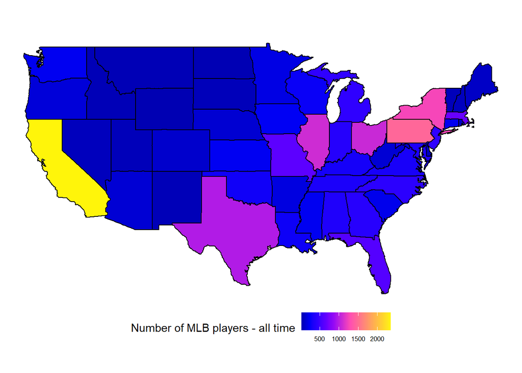

```r
Master %>%
  filter(birthCountry == "USA") %>%
  count(birthState) %>%
  left_join(state_link, by = c("birthState" = "abbrev")) %>%
  select(name, num_players = n) %>%
  right_join(us48,
             by = c("name" = "region")) %>%
  ggplot(mapping = aes(x = long, y = lat)) +
  geom_polygon(mapping = aes(group = group,
                             fill = num_players),
               color = 'black') +
  coord_quickmap() +
  scale_fill_gradientn("Number of MLB players - all time", colours = sf.colors(12)) +
  theme_void() +
  theme(legend.position = "bottom") +
  theme(legend.text = element_text(size = 6.5))
```

### map with geom_sf()

Alternatively, if the spatial data are contained within an `sf` object, we can visualize the choropleth with `geom_sf()`. If we continue to use the contiguous 48 state map from the `maps` package, we will need to **convert** the data to an `sf` object. This is easy to do thanks to the `st_as_sf()` function. However, rather than using `us48` (which was created via the `map_data()` function), we will convert the spatial data directly from the `maps` package. The code chunk below uses the `::` notation to access the necessary function with the `maps` package. This way we do not have to load in the `maps` package. The result is assigned to the `usa_sf` object.

```r
usa_sf <- st_as_sf( maps::map('state', fill=TRUE, plot=FALSE) )

usa_sf %>% class()
```

```
## [1] "sf"         "data.frame"
```

The `class()` function confirms that `usa_sf` is indeed an `sf` object. The code chunk below displays the `usa_sf` to the screen. Again we first see summary information about the number of features and fields, as well as the bounding box around the entire map.

```r
usa_sf
```

```
## Simple feature collection with 49 features and 1 field
## Geometry type: MULTIPOLYGON
## Dimension:     XY
## Bounding box:  xmin: -124.6813 ymin: 25.12993 xmax: -67.00742 ymax: 49.38323
## Geodetic CRS:  WGS 84
## First 10 features:
##                      ID                           geom
## 1               alabama MULTIPOLYGON (((-87.46201 3...
## 2               arizona MULTIPOLYGON (((-114.6374 3...
## 3              arkansas MULTIPOLYGON (((-94.05103 3...
## 4            california MULTIPOLYGON (((-120.006 42...
## 5              colorado MULTIPOLYGON (((-102.0552 4...
## 6           connecticut MULTIPOLYGON (((-73.49902 4...
## 7              delaware MULTIPOLYGON (((-75.80231 3...
## 8  district of columbia MULTIPOLYGON (((-77.13731 3...
## 9               florida MULTIPOLYGON (((-85.01548 3...
## 10              georgia MULTIPOLYGON (((-80.89018 3...
```

We can double check the `sf` object field names with the `names()` function.

```r
usa_sf %>% names()
```

```
## [1] "ID"   "geom"
```

Thus, the state names in `usa_sf` correspond to the `ID` column. We must therefore merge the player counts per state to `usa_sf` via the link table. Rather than performing all operations - data manipulation, both joins, and visualization - in a single pipeline, let’s first assign the player summary counts to the `players_per_state` object.

```r
players_per_state <- Master %>%
  filter(birthCountry == "USA") %>%
  count(birthState) %>%
  left_join(state_link, by = c("birthState" = "abbrev")) %>%
  select(name, num_players = n)
```

The `players_per_state` data are joined to the `usa_sf` `sf` object via a left-join. The result is pipped into `ggplot()` and the choropleth is created with the appropriate `fill` aesthetic with `geom_sf()` in the code chunk below.

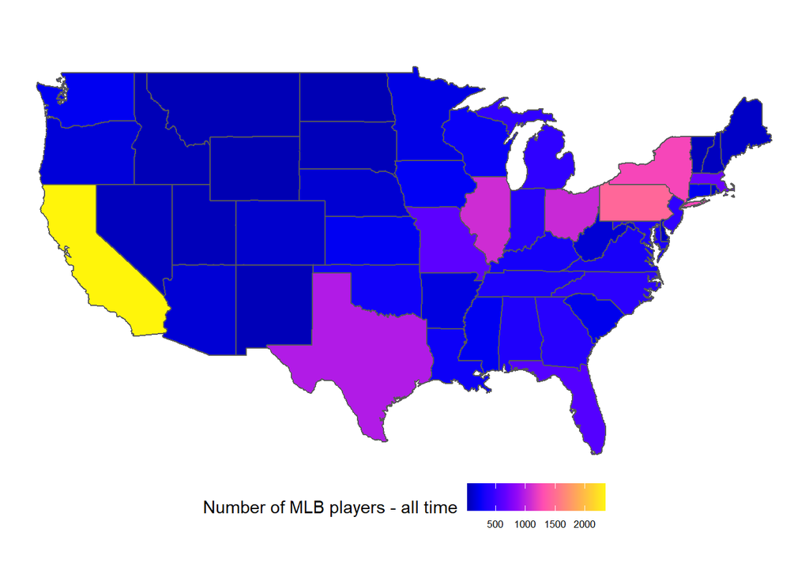

```r
usa_sf %>%
  left_join(players_per_state,
            by = c("ID" = "name")) %>%
  ggplot() +
  geom_sf(mapping = aes(fill = num_players)) +
  scale_fill_gradientn("Number of MLB players - all time", colours = sf.colors(12)) +
  theme_void() +
  theme(legend.position = "bottom") +
  theme(legend.text = element_text(size = 6.5))
```

As we can see above, the visualizations are consistent! Whether we want to use a “tidy” data set and `geom_polygon()` or an `sf` object with `geom_sf()`, the key point of this example was to show how the data of interest can be **joined** to spatial information.

### World data

As one last example, let’s visualize the number of players born per country. This way we can practice working with a map of the world, rather than a single country. Although we have already loaded in world spatial data via the `map_data()` function, we will use the `rnaturalearth` package to demonstrate working with data from another source. `rnaturalearth` is an `R` package which allows accessing data from [Natural Earth](https://www.naturalearthdata.com/), a free vector and raster map data repository at various spatial resolutions. Please see the [rnaturalearth getting started vignette](https://cran.r-project.org/web/packages/rnaturalearth/vignettes/rnaturalearth.html) to learn more about `rnaturalearth`.

To run the following examples, you must download and install the `rnaturalearth` package. The code chunk below loads in `rnaturalearth`.

```r
library(rnaturalearth)
```

We can load in the spatial data associated with countries using the `ne_countries()` function. If we do not specify any arguments to `ne_countries()` we will get the spatial data for all countries the world. The code chunk below gets the spatial world data and assigns the result to the `world` object.

```r
world <- ne_countries()

world %>% class()
```

```
## [1] "SpatialPolygonsDataFrame"
## attr(,"package")
## [1] "sp"
```

As we see in the output display above, `world` is an `sp` class object. To use the set of functions we have discussed in this report, we must convert from the `sp` class to the `sf` class. Again, we can use the `st_as_sf()` function to convert the data type.

```r
world <- st_as_sf( world )

world %>% class()
```

```
## [1] "sf"         "data.frame"
```

With `world` as the `sf` data type, we can now use `geom_sf()` to visualize the countries.

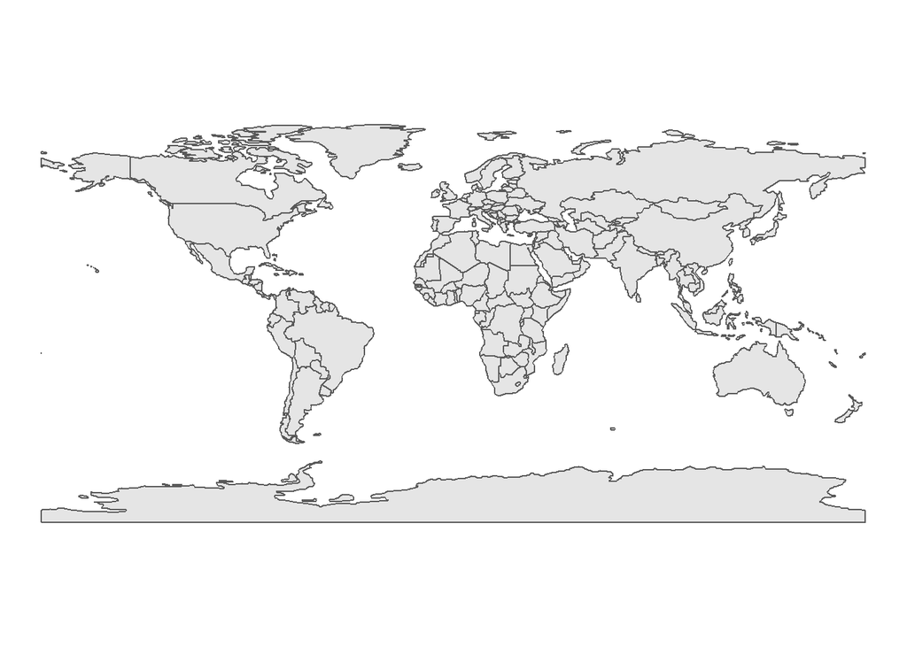

```r
world %>%
  ggplot() +
  geom_sf() +
  theme_void()
```

Now that we have the necessary spatial data, let’s return our attention back to the `Lahman` data set. The `Master` table includes the player’s birth country as the `birthCountry` column. The code chunk counts the number of players born in each country.

```r
Master %>%
  count(birthCountry) %>%
  arrange(desc(n))
```

```
##      birthCountry     n
## 1             USA 17395
## 2            D.R.   792
## 3       Venezuela   425
## 4            P.R.   270
## 5             CAN   255
## 6            Cuba   223
## 7          Mexico   136
## 8           Japan    70
## 9          Panama    65
## 10           <NA>    61
## 11 United Kingdom    52
## 12        Ireland    50
## 13        Germany    44
## 14      Australia    32
```

[output cut: 44 more lines]

The printed output shows us that the `Lahman` package uses a mix of nation abbreviations and names. For example Mexico and Japan are spelled out, but the Dominican Republic is abbreviated as D.R. There are several other countries with abbreviations (and even a few countries with typos) in the `Lahman` data set. Let’s check naming convention for the `sf` converted `world` object. As shown below, there are 64 columns (fields) in the `world` object!

```r
world %>% names()
```

```
##  [1] "scalerank"  "featurecla" "labelrank"  "sovereignt" "sov_a3"
##  [6] "adm0_dif"   "level"      "type"       "admin"      "adm0_a3"
## [11] "geou_dif"   "geounit"    "gu_a3"      "su_dif"     "subunit"
## [16] "su_a3"      "brk_diff"   "name"       "name_long"  "brk_a3"
## [21] "brk_name"   "brk_group"  "abbrev"     "postal"     "formal_en"
## [26] "formal_fr"  "note_adm0"  "note_brk"   "name_sort"  "name_alt"
## [31] "mapcolor7"  "mapcolor8"  "mapcolor9"  "mapcolor13" "pop_est"
## [36] "gdp_md_est" "pop_year"   "lastcensus" "gdp_year"   "economy"
## [41] "income_grp" "wikipedia"  "fips_10"    "iso_a2"     "iso_a3"
## [46] "iso_n3"     "un_a3"      "wb_a2"      "wb_a3"      "woe_id"
## [51] "adm0_a3_is" "adm0_a3_us" "adm0_a3_un" "adm0_a3_wb" "continent"
## [56] "region_un"  "subregion"  "region_wb"  "name_len"   "long_len"
## [61] "abbrev_len" "tiny"       "homepart"   "geometry"
```

The country name is stored in the `name` field, as confirmed by looking at a print out of a few fields below.

```r
world %>%
  select(name, continent, geometry)
```

```
## Simple feature collection with 177 features and 2 fields
## Geometry type: MULTIPOLYGON
## Dimension:     XY
## Bounding box:  xmin: -180 ymin: -90 xmax: 180 ymax: 83.64513
## CRS:           +proj=longlat +datum=WGS84 +no_defs +ellps=WGS84 +towgs84=0,0,0
## First 10 features:
##                     name               continent                       geometry
## 0            Afghanistan                    Asia MULTIPOLYGON (((61.21082 35...
## 1                 Angola                  Africa MULTIPOLYGON (((16.32653 -5...
## 2                Albania                  Europe MULTIPOLYGON (((20.59025 41...
## 3   United Arab Emirates                    Asia MULTIPOLYGON (((51.57952 24...
## 4              Argentina           South America MULTIPOLYGON (((-65.5 -55.2...
## 5                Armenia                    Asia MULTIPOLYGON (((43.58275 41...
## 6             Antarctica              Antarctica MULTIPOLYGON (((-59.57209 -...
## 7 Fr. S. Antarctic Lands Seven seas (open ocean) MULTIPOLYGON (((68.935 -48....
## 8              Australia                 Oceania MULTIPOLYGON (((145.398 -40...
## 9                Austria                  Europe MULTIPOLYGON (((16.97967 48...
```

We can check for a specific string pattern using the `stringr::str_detect()` function. This allows us to look for a portion of a country name to double check how the `world` `sf` object has the name written. For example, to find the United States we can “look for” or detect any country with `"United"` in the `name` column of `world`. As we see below, the USA is listed as `'United States'`.

```r
world %>%
  select(name, continent, geometry) %>%
  filter(stringr::str_detect(name, "United"))
```

```
## Simple feature collection with 3 features and 2 fields
## Geometry type: MULTIPOLYGON
## Dimension:     XY
## Bounding box:  xmin: -171.7911 ymin: 18.91619 xmax: 56.39685 ymax: 71.35776
## CRS:           +proj=longlat +datum=WGS84 +no_defs +ellps=WGS84 +towgs84=0,0,0
##                   name     continent                       geometry
## 1 United Arab Emirates          Asia MULTIPOLYGON (((51.57952 24...
## 2       United Kingdom        Europe MULTIPOLYGON (((-5.661949 5...
## 3        United States North America MULTIPOLYGON (((-155.5421 1...
```

Next, let’s check how the Dominican Republic is spelled within the `world` `sf` object.

```r
world %>%
  select(name, continent, geometry) %>%
  filter(stringr::str_detect(name, "Rep"))
```

```
## Simple feature collection with 5 features and 2 fields
## Geometry type: MULTIPOLYGON
## Dimension:     XY
## Bounding box:  xmin: -71.94511 ymin: -13.25723 xmax: 130.78 ymax: 51.11727
## CRS:           +proj=longlat +datum=WGS84 +no_defs +ellps=WGS84 +towgs84=0,0,0
##                   name     continent                       geometry
## 1 Central African Rep.        Africa MULTIPOLYGON (((15.27946 7....
## 2      Dem. Rep. Congo        Africa MULTIPOLYGON (((30.83386 3....
## 3           Czech Rep.        Europe MULTIPOLYGON (((16.96029 48...
## 4       Dominican Rep. North America MULTIPOLYGON (((-71.71236 1...
## 5      Dem. Rep. Korea          Asia MULTIPOLYGON (((130.64 42.3...
```

We again have a missmatch in the Lahman country naming styles and our spatial data object. We will use another link table to enable joining the data sets together. The link table created below is not comprehensive. It was put together to demonstrate how to do this, but additional work is required to check if all countries are correctly included in the link table.

```r
lahman_link <- tibble::tibble(
  birthCountry = c("USA", "D.R.", "CAN", "P.R.", "Viet Nam", "South Korea"),
  name = c("United States", "Dominican Rep.", "Canada", "Puerto Rico", "Vietnam", "Korea")
)
```

Joining `lahman_link` to the `Master` table by `birthCountry` adds the `name` column to `Lahman`. However, some missing values are present!

```r
Master %>%
  left_join(lahman_link, by = "birthCountry") %>%
  select(playerID, birthCountry, name) %>%
  purrr::map_dbl(~sum(is.na(.)))
```

```
##     playerID birthCountry         name
##            0           61         1356
```

A missing in the `name` column represents we can use the `birthCountry` as is. An example set of rows is shown below when `name` is missing.

```r
Master %>%
  left_join(lahman_link, by = "birthCountry") %>%
  select(playerID, birthCountry, name) %>%
  filter(is.na(name)) %>%
  tibble::as_tibble()
```

```
## # A tibble: 1,356 x 3
##    playerID  birthCountry name
##    <chr>     <chr>        <chr>
##  1 abreubo01 Venezuela    <NA>
##  2 abreujo02 Cuba         <NA>
##  3 aceveal01 Mexico       <NA>
##  4 aceveju01 Mexico       <NA>
##  5 acostcy01 Mexico       <NA>
##  6 acosted01 Panama       <NA>
##  7 acostjo01 Cuba         <NA>
##  8 acostma01 Panama       <NA>
##  9 acostme01 Cuba         <NA>
## 10 acunaro01 Venezuela    <NA>
## # ... with 1,346 more rows
```

The `name` column is mutated and reassigned to the result of an `ifelse()` function. The `ifelse()` function is an in-line if-else. A conditional test is provided in the first argument, if that value is TRUE the second argument is returned. Otherwise, the third argument is returned. We can therefore remove many of the missing values for `name` by setting `name` equal to `birthCountry` if `name` is missing. As shown below, the remaining missing rows for `name` correspond to those associated with missing `birthCountry` values.

```r
Master %>%
  left_join(lahman_link, by = "birthCountry") %>%
  mutate(name = ifelse(is.na(name), birthCountry, name)) %>%
  select(playerID, birthCountry, name) %>%
  filter(is.na(name)) %>%
  tibble::as_tibble()
```

```
## # A tibble: 61 x 3
##    playerID  birthCountry name
##    <chr>     <chr>        <chr>
##  1 bolan01   <NA>         <NA>
##  2 booth01   <NA>         <NA>
##  3 brittji01 <NA>         <NA>
##  4 brown01   <NA>         <NA>
##  5 carroch01 <NA>         <NA>
##  6 caseybi01 <NA>         <NA>
##  7 connore01 <NA>         <NA>
##  8 crawfge01 <NA>         <NA>
##  9 donnepe01 <NA>         <NA>
## 10 drewda01  <NA>         <NA>
## # ... with 51 more rows
```

We can now count the number of players associated with each country. The code chunk below assigns the result to the `players_per_country` object.

```r
players_per_country <- Master %>%
  left_join(lahman_link, by = "birthCountry") %>%
  mutate(name = ifelse(is.na(name), birthCountry, name)) %>%
  count(name) %>%
  arrange(desc(n))

players_per_country %>% glimpse()
```

```
## Rows: 58
## Columns: 2
## $ name <chr> "United States", "Dominican Rep.", "Venezuela", "Puerto Rico", "C~
## $ n    <int> 17395, 792, 425, 270, 255, 223, 136, 70, 65, 61, 52, 50, 44, 32, ~
```

The choropleth for the number of players born per country is created in the code chunk below. The `players_per_country` object is joined to `world` via a `left_join()` by the `name` column. Since `world` is an `sf` object, the map is created with `geom_sf()`.

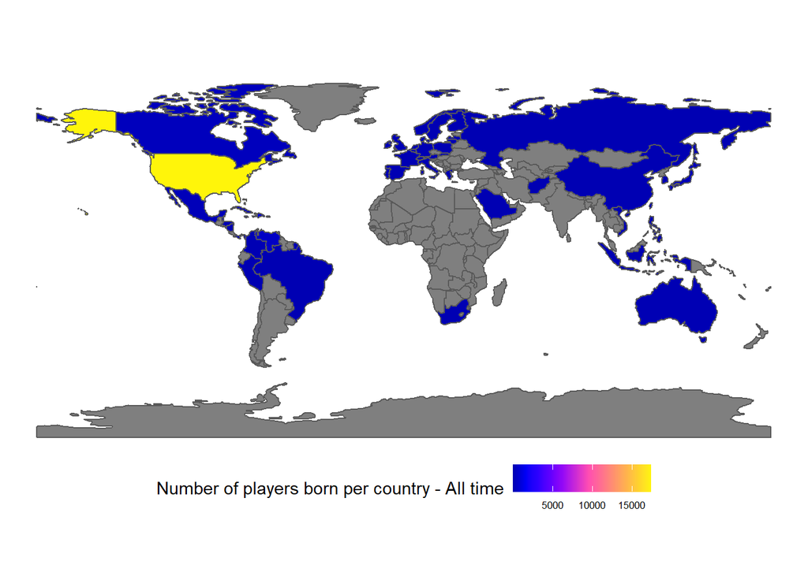

```r
world %>%
  left_join(players_per_country, by = "name") %>%
  ggplot() +
  geom_sf(mapping = aes(fill = n)) +
  scale_fill_gradientn("Number of players born per country - All time", colours = sf.colors(12)) +
  theme_void() +
  theme(legend.position = "bottom",
        legend.text = element_text(size = 6.5))
```

Since one country dominates the counts, let’s convert the number of players into a categorical variable. The deciles for the number of players per country are shown below to help get a sense of useful bin break points.

```r
players_per_country %>%
  pull(n) %>%
  quantile(seq(0, 1, by = 0.1))
```

```
##      0%     10%     20%     30%     40%     50%     60%     70%     80%     90%
##     1.0     1.0     1.0     1.0     2.0     4.5     7.0    15.9    47.6   162.1
##    100%
## 17395.0
```

The binned player counts variable is added to `players_per_country` using the `cut()` function.

```r
players_per_country <- players_per_country %>%
  mutate(player_bins = cut(n,
                           breaks = c(0,
                                      1,
                                      3,
                                      5,
                                      10,
                                      20,
                                      50,
                                      100,
                                      200,
                                      400,
                                      800,
                                      max(n)),
                           include.lowest = TRUE))
```

The choropleth with the binned color scale is shown in the code chunk below.

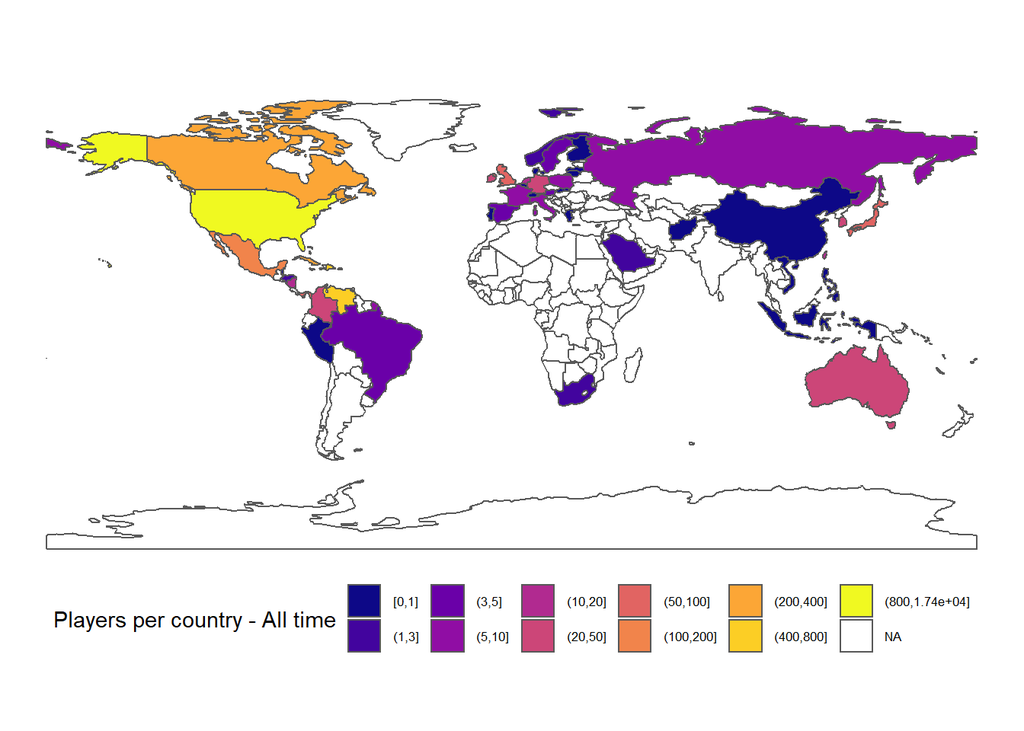

```r
world %>%
  left_join(players_per_country, by = "name") %>%
  ggplot() +
  geom_sf(mapping = aes(fill = player_bins)) +
  scale_fill_viridis_d("Players per country - All time", option = 'plasma') +
  theme_void() +
  theme(legend.position = "bottom",
        legend.text = element_text(size = 6.5)) +
  guides(fill = guide_legend(nrow = 2))
```

Since no players were born in Antarctica, let’s remove it from the map.

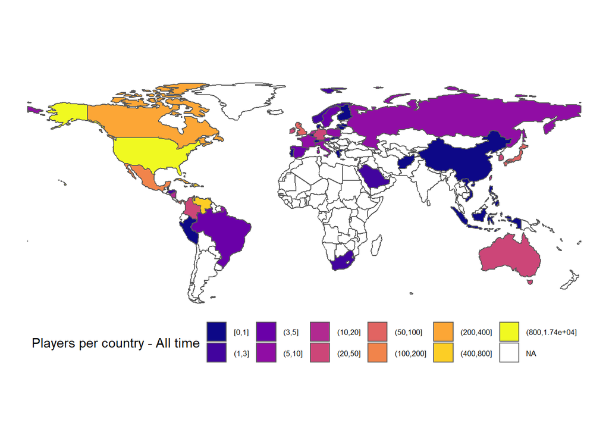

```r
world %>%
  left_join(players_per_country, by = "name") %>%
  filter(continent != "Antarctica") %>%
  ggplot() +
  geom_sf(mapping = aes(fill = player_bins)) +
  scale_fill_viridis_d("Players per country - All time", option = 'plasma') +
  theme_void() +
  theme(legend.position = "bottom",
        legend.text = element_text(size = 6.5)) +
  guides(fill = guide_legend(nrow = 2))
```

## Conclusion

This report demonstrated how to create maps using several plotting packages, but mostly focused on `ggplot2` and the `sf` package. Please consult the plotly-r book for more examples and other packages you could consider.